# EDA on Prosper Loan by TEMITOPE ADEBIYI

```r
knitr::opts_chunk$set(echo=FALSE, warning=FALSE, message=FALSE)
```

```
## [1] "C:/Users/Crowntopsss/Downloads"
```

## Univariate Plots Section

```
## 'data.frame':    113937 obs. of  81 variables:
##  $ ListingKey                         : Factor w/ 113066 levels "00003546482094282EF90E5",..: 7180 7193 6647 6669 6686 6689 6699 6706 6687 6687 ...
##  $ ListingNumber                      : int  193129 1209647 81716 658116 909464 1074836 750899 768193 1023355 1023355 ...
##  $ ListingCreationDate                : Factor w/ 113064 levels "2005-11-09 20:44:28.847000000",..: 14184 111894 6429 64760 85967 100310 72556 74019 97834 97834 ...
##  $ CreditGrade                        : Factor w/ 9 levels "","A","AA","B",..: 5 1 8 1 1 1 1 1 1 1 ...
##  $ Term                               : int  36 36 36 36 36 60 36 36 36 36 ...
##  $ LoanStatus                         : Factor w/ 12 levels "Cancelled","Chargedoff",..: 3 4 3 4 4 4 4 4 4 4 ...
##  $ ClosedDate                         : Factor w/ 2803 levels "","2005-11-25 00:00:00",..: 1138 1 1263 1 1 1 1 1 1 1 ...
##  $ BorrowerAPR                        : num  0.165 0.12 0.283 0.125 0.246 ...
##  $ BorrowerRate                       : num  0.158 0.092 0.275 0.0974 0.2085 ...
##  $ LenderYield                        : num  0.138 0.082 0.24 0.0874 0.1985 ...
##  $ EstimatedEffectiveYield            : num  NA 0.0796 NA 0.0849 0.1832 ...
##  $ EstimatedLoss                      : num  NA 0.0249 NA 0.0249 0.0925 ...
##  $ EstimatedReturn                    : num  NA 0.0547 NA 0.06 0.0907 ...
##  $ ProsperRating..numeric.            : int  NA 6 NA 6 3 5 2 4 7 7 ...
```

[output cut: 67 more lines]

This is the structure of the data showing number of row and colunms. We can see the information for each column of the data, giving us the data type in each of the columns.

```
##    Min. 1st Qu.  Median    Mean 3rd Qu.    Max.
##   12.00   36.00   36.00   40.83   36.00   60.00
```

```
##              Cancelled             Chargedoff              Completed
##                      5                  11992                  38074
##                Current              Defaulted FinalPaymentInProgress
##                  56576                   5018                    205
##   Past Due (>120 days)   Past Due (1-15 days)  Past Due (16-30 days)
##                     16                    806                    265
##  Past Due (31-60 days)  Past Due (61-90 days) Past Due (91-120 days)
##                    363                    313                    304
```

```
##    Min. 1st Qu.  Median    Mean 3rd Qu.    Max.    NA's
##    1.00    4.00    6.00    5.95    8.00   11.00   29084
```

```
##    Min. 1st Qu.  Median    Mean 3rd Qu.    Max.
##  0.0000  0.1340  0.1840  0.1928  0.2500  0.4975
```

```
##                    Employed     Full-time Not available  Not employed
##          2255         67322         26355          5347           835
##         Other     Part-time       Retired Self-employed
##          3806          1088           795          6134
```

```
##                                                        Accountant/CPA
##                               3588                               3233
##           Administrative Assistant                            Analyst
##                               3688                               3602
##                          Architect                           Attorney
##                                213                               1046
##                          Biologist                         Bus Driver
##                                125                                316
##                         Car Dealer                            Chemist
##                                180                                145
##                      Civil Service                             Clergy
##                               1457                                196
##                           Clerical                Computer Programmer
##                               3164                               4478
##                       Construction                            Dentist
##                               1790                                 68
##                             Doctor                Engineer - Chemical
##                                494                                225
##              Engineer - Electrical              Engineer - Mechanical
##                               1125                               1406
##                          Executive                            Fireman
##                               4311                                422
##                   Flight Attendant                       Food Service
##                                123                               1123
##            Food Service Management                          Homemaker
##                               1239                                120
##                           Investor                              Judge
##                                214                                 22
##                            Laborer                        Landscaping
##                               1595                                236
##                 Medical Technician                  Military Enlisted
##                               1117                               1272
##                   Military Officer                       Nurse's Aide
##                                346                                491
##                        Nurse (LPN)                         Nurse (RN)
##                                492                               2489
##                              Other                         Pharmacist
##                              28617                                257
##         Pilot - Private/Commercial  Police Officer/Correction Officer
##                                199                               1578
```

[output cut: 13 more lines]

```
##                                741                                 41
## Student - College Graduate Student           Student - College Junior
##                                245                                112
##           Student - College Senior        Student - College Sophomore
##                                188                                 69
##        Student - Community College         Student - Technical School
##                                 28                                 16
##                            Teacher                     Teacher's Aide
##                               3759                                276
##              Tradesman - Carpenter            Tradesman - Electrician
##                                120                                477
##               Tradesman - Mechanic                Tradesman - Plumber
##                                951                                102
##                       Truck Driver                    Waiter/Waitress
##                               1675                                436
```

```
##    Min. 1st Qu.  Median    Mean 3rd Qu.    Max.
##       0    3200    4667    5608    6825 1750003
```

```
##    Min. 1st Qu.  Median    Mean 3rd Qu.    Max.
##     0.0   131.6   217.7   272.5   371.6  2251.5
```

The above is the summary of some columns in the Dataset.

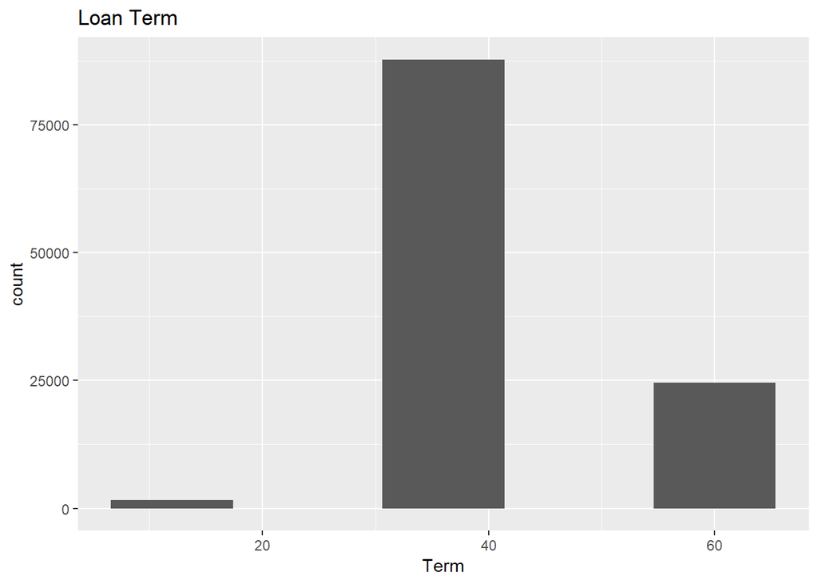

The most frequent loan term people went for is 3 years followed by 5 years and the least is 1 year.

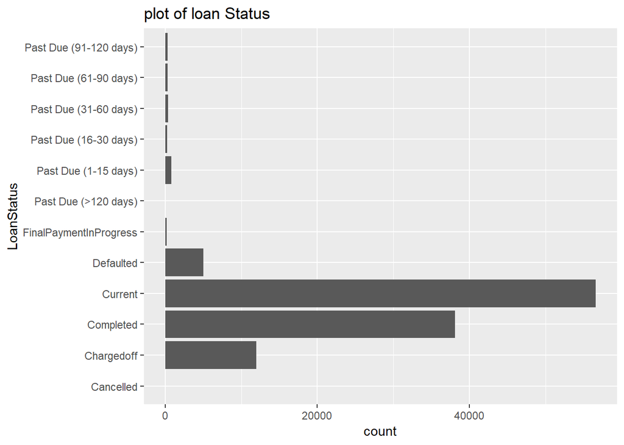

The cancelled transcations were just 5 which doesnt look obvious. From the data given most customers are still on current. the completed loan to defaulted loan is high more of completed. The highest past due loan days is (1-15 days).

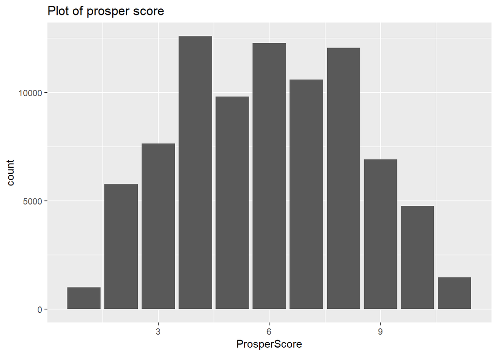

The prosperscore is a normal distribution, with most score between 4 and 7 most of the transactions dont have a good prosper rating.

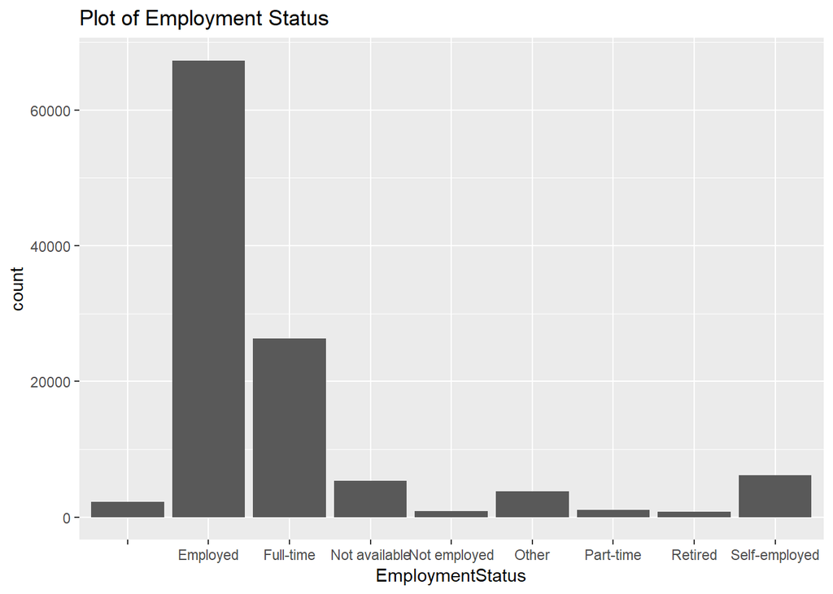

MOst approved loans are of the employed and the fulltime category.

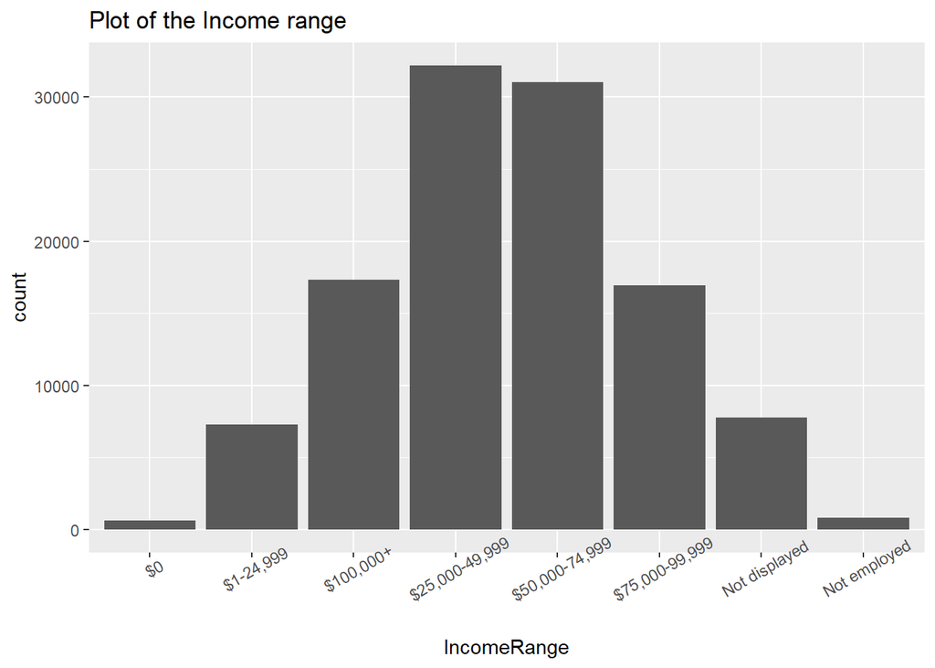

The income range of most of the clients is between $25,000 and $74,000.

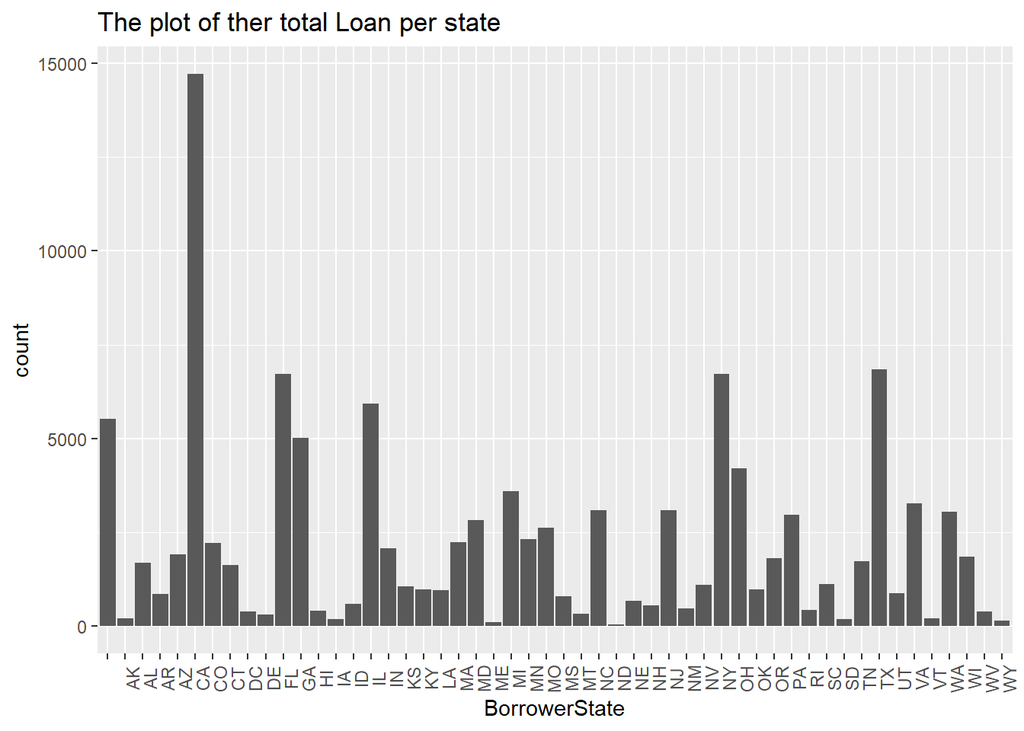

This above plot shows that California haves the highest amount of loan count which is also the most populated state in the United states. The only way we can work on this data is to relate it with the total population of each state.

# Univariate Analysis

### What is/are the main feature(s) of interest in your dataset?

The features of interest i will be considering in this dataset are below: - Term - Loan status - Prosper Score - Occupation - Employment status - Income Range - Total Prosper loan - Listing category - Investors - Recommendation - Stated monthly income - Loan original amount - Loan origination date

### What other features in the dataset do you think will help support your

Investigation into your feature(s) of interest? -Debt to income ratio -Investors -Borrower state

### Did you create any new variables from existing variables in the dataset?

Yes but they are below

### Of the features you investigated, were there any unusual distributions?

I did not tidy, adjust, or change the form of the data.

## Bivariate Plots Section

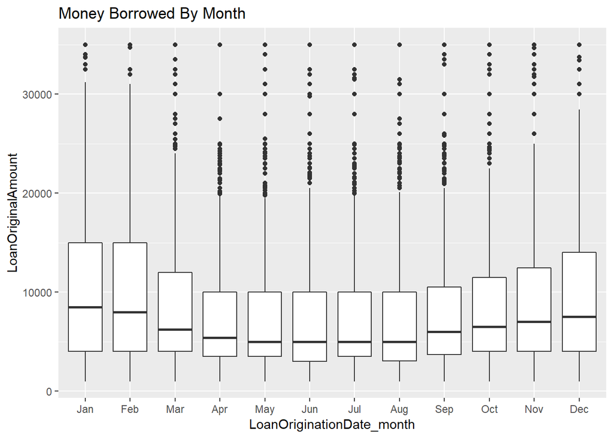

This above plot shows what I predicted how the months will affect the total amount being borrowed in a year. So the amount of loan increases towards the end of the year and reduces from the begining of the year.

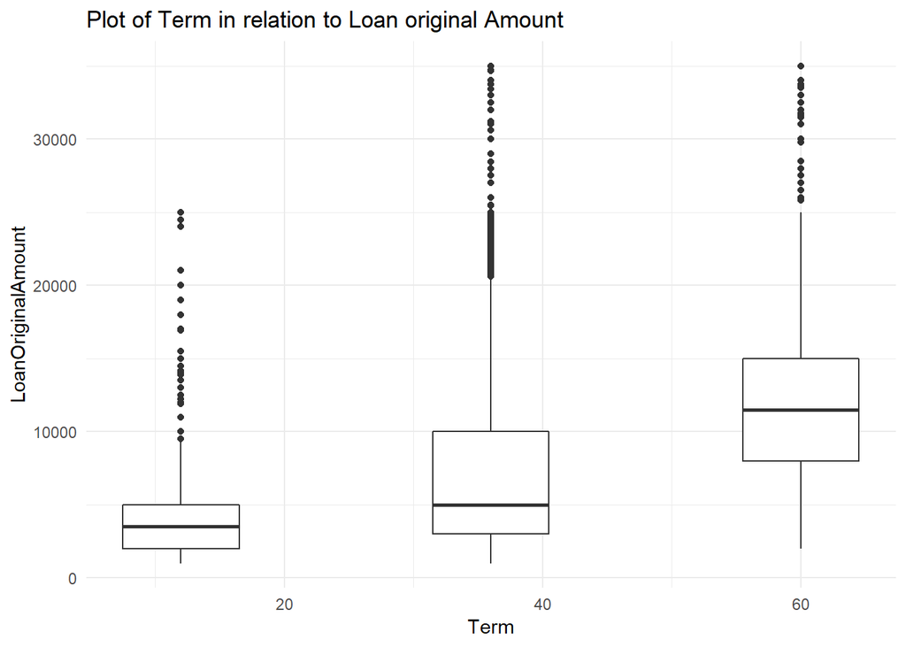

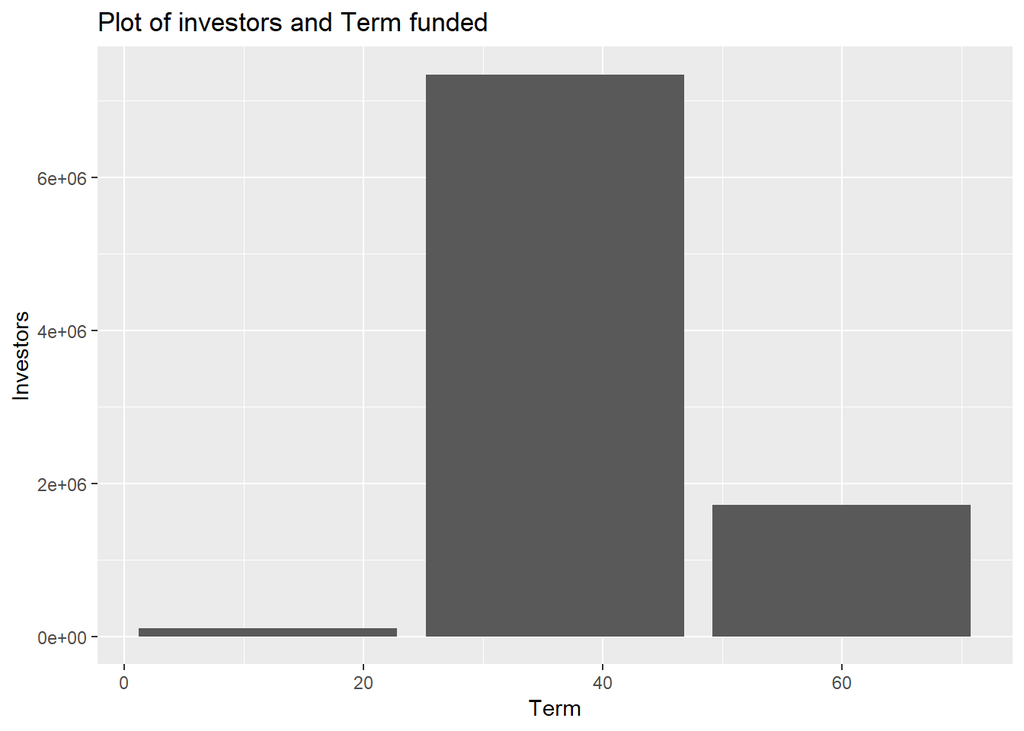

[output not shown]

[output cut: 306 more lines]

[output not shown]

Wow we see above that there are more investors for the 36 month that any other term and also show less interest of investors in the 12 month term.

```
##              Cancelled             Chargedoff              Completed
##                      5                  11992                  38074
##                Current              Defaulted FinalPaymentInProgress
##                  56576                   5018                    205
##   Past Due (>120 days)   Past Due (1-15 days)  Past Due (16-30 days)
##                     16                    806                    265
##  Past Due (31-60 days)  Past Due (61-90 days) Past Due (91-120 days)
##                    363                    313                    304
```

```
##                    Employed     Full-time Not available  Not employed
##          2255         67322         26355          5347           835
##         Other     Part-time       Retired Self-employed
##          3806          1088           795          6134
```

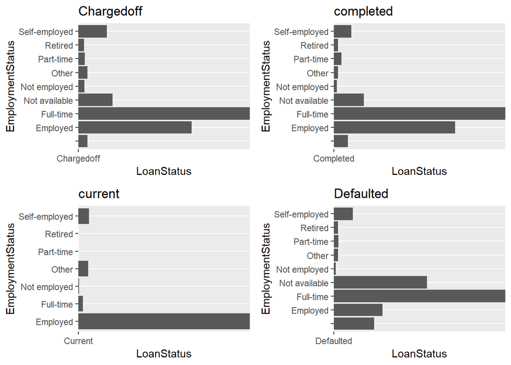

From this differrent plots above currnet loan status is being domonated by hte employed, most Defaulters of the loan are the fulltime followed by the non- available. The most charged off and most completed are the full time and the employed.

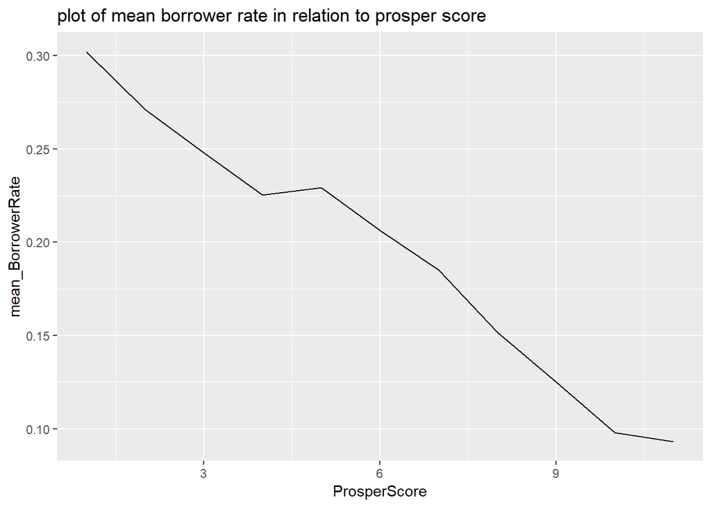

Amazing what is going on in the above plot, there is a trend which shows that the lower your rating the higher the rate.

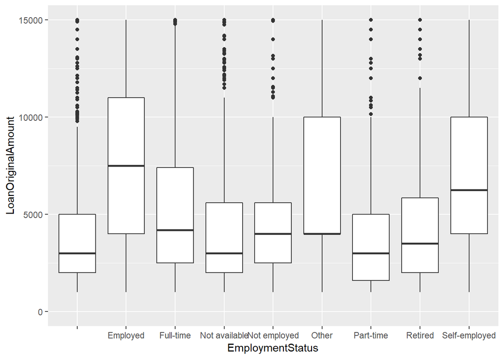

This plot looks predictable, Employed has the highest average loan amount, retired has a low average loan amount.

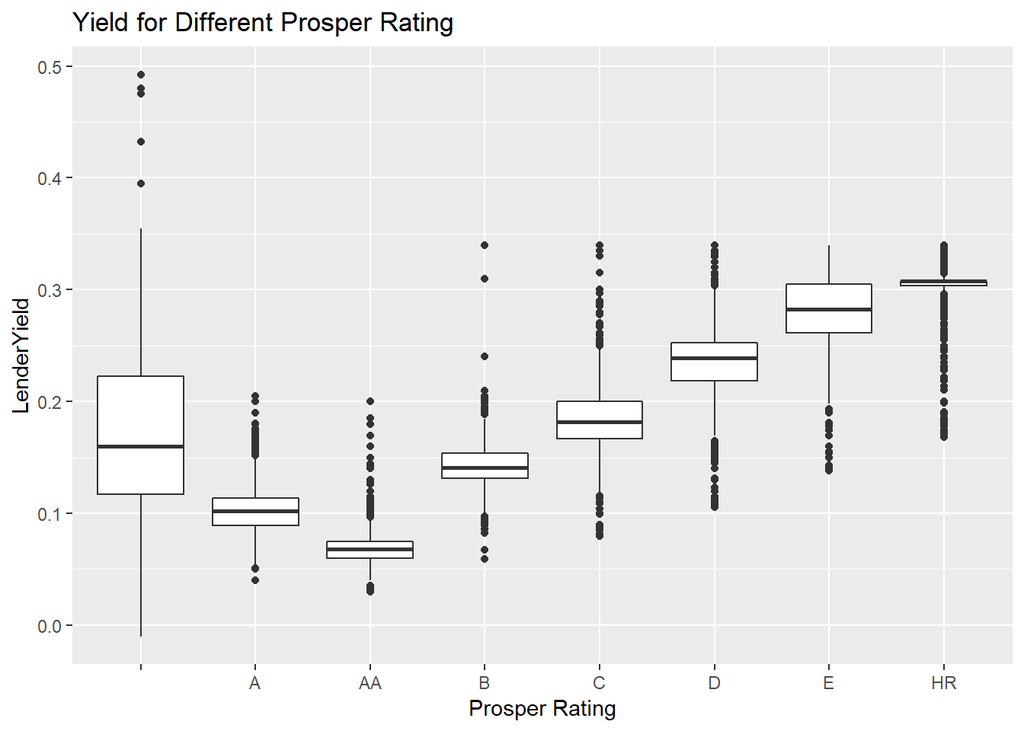

This plot shows a medium correlation between them.

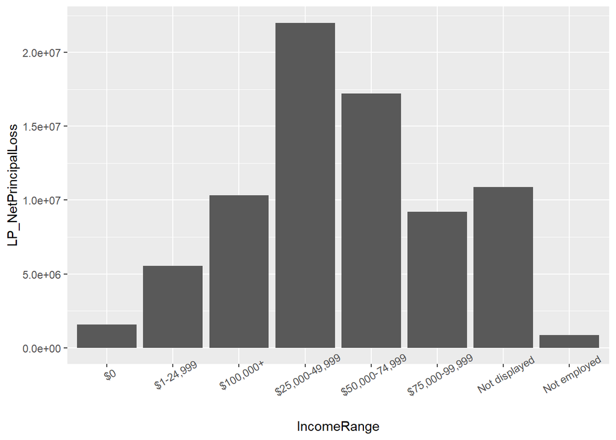

This plot shows that this income range ($25,000 - $49,999) has the highest net principal loss and there is no correlation here.

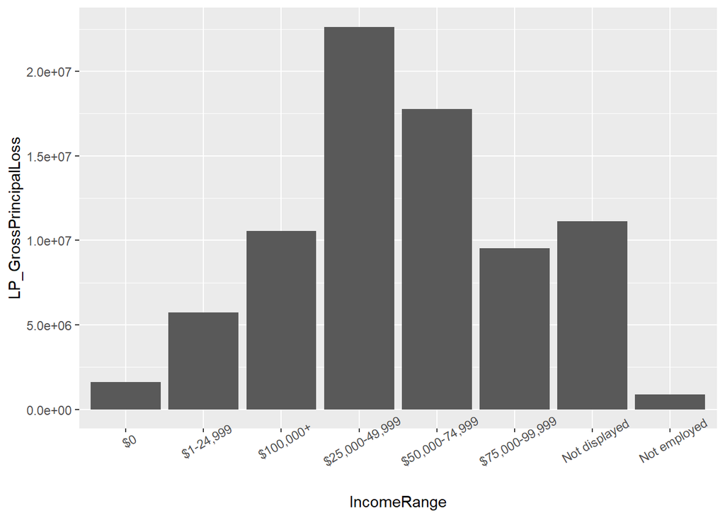

This plot is almost the same with the plot of income range and net principal loss.

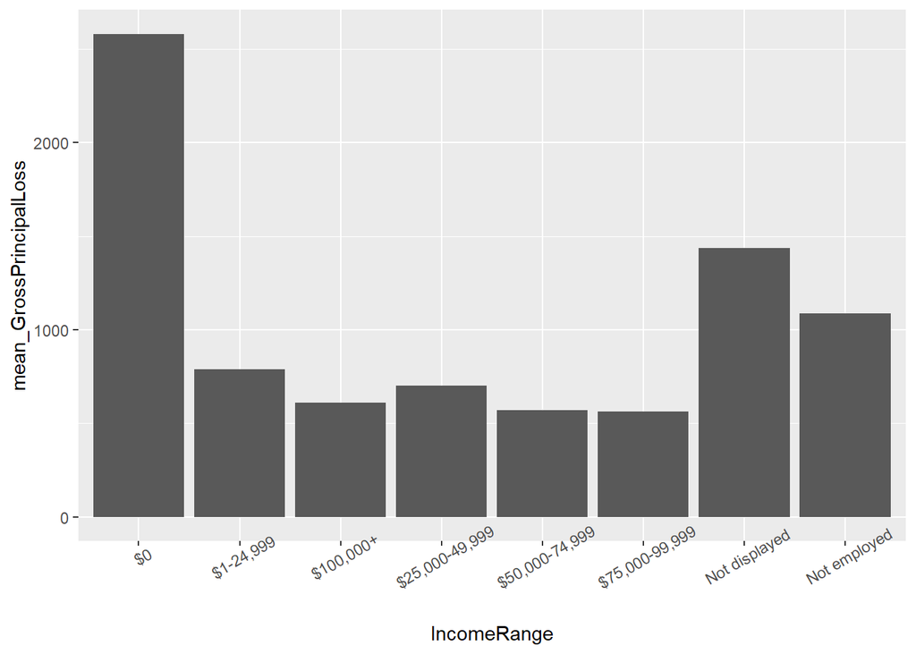

# Bivariate Analysis

### Did you observe any interesting relationships between the other features

There is a trend which shows that the lower your rating the higher the rate.

### What was the strongest relationship you found?

mean borrower rate and prosper score.

# Multivariate Plots Section

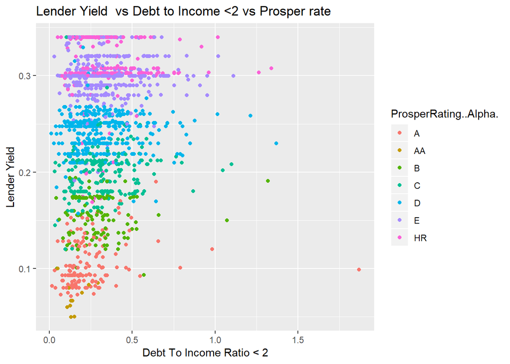

This plot reveals the relationship between lender yeild, debt to income ratio and prosper rating. good prosper rating A and AA have low lenders yield and also low debt to income ration in other word they det low interest on their loan. In The plot medium and bad rating have a large range of debt to income ratio and their lender yield increase respectively.

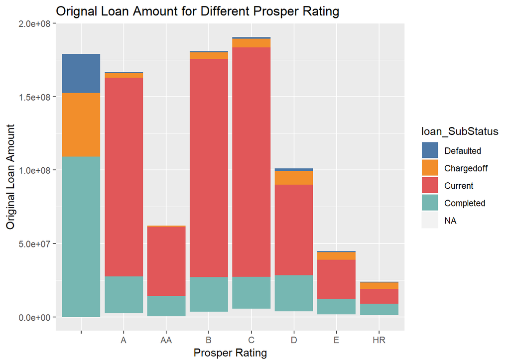

Accross the prsoper rating the current status has high proportion and there is a decrease in original loan for, prosper rating C to HR.

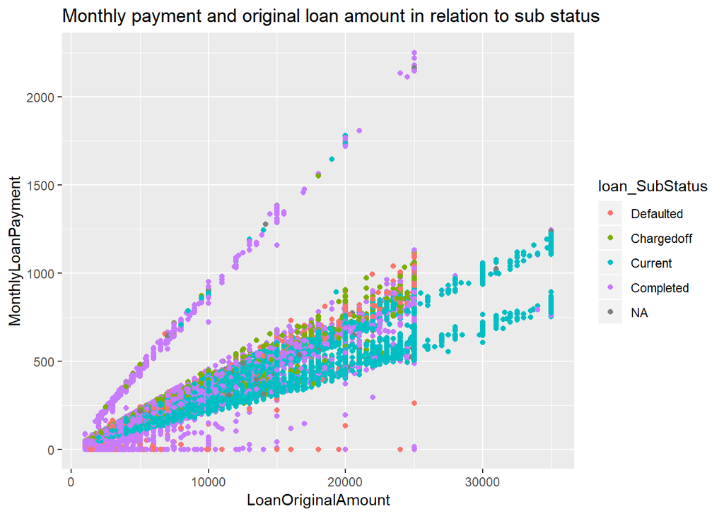

There is no much revelation in this plot, what i can see is that people who have loan status as current have a good correlation between monthly payment and loan original amount.completed loans has a poor correlation but showed that the loan payment were high in respective of the loan original amount in order words the payed more ever month in order to complete the loan fast, and the current status are paying it in bit.

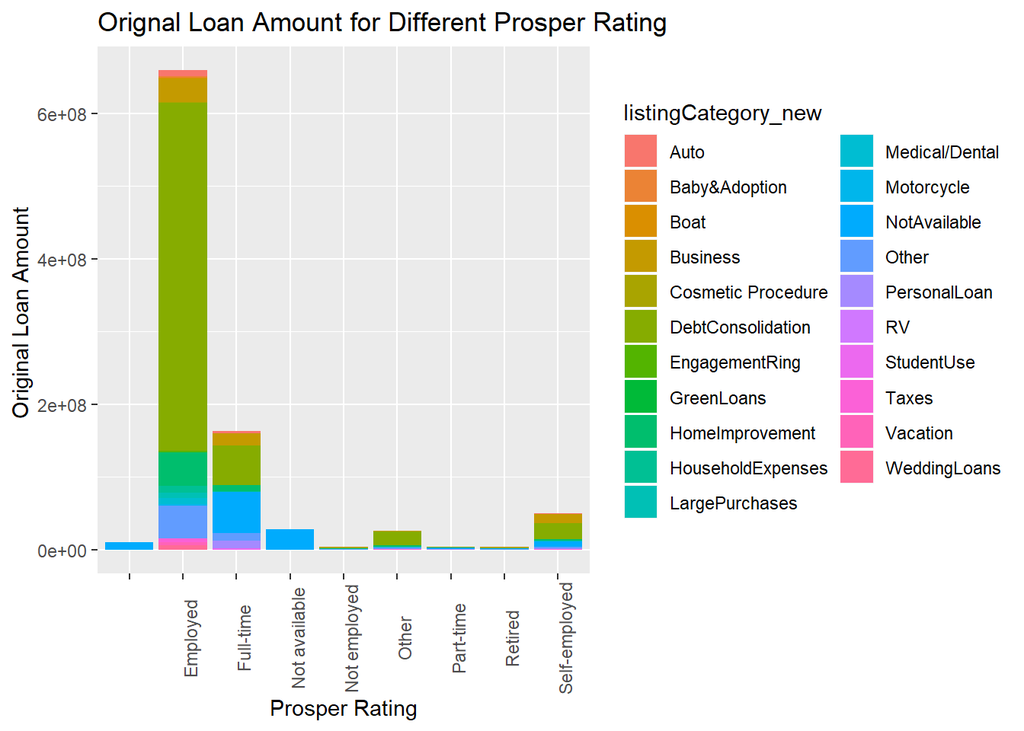

This above plot is crowded it is hard to get any thing from the above but i will choose the most important variable.

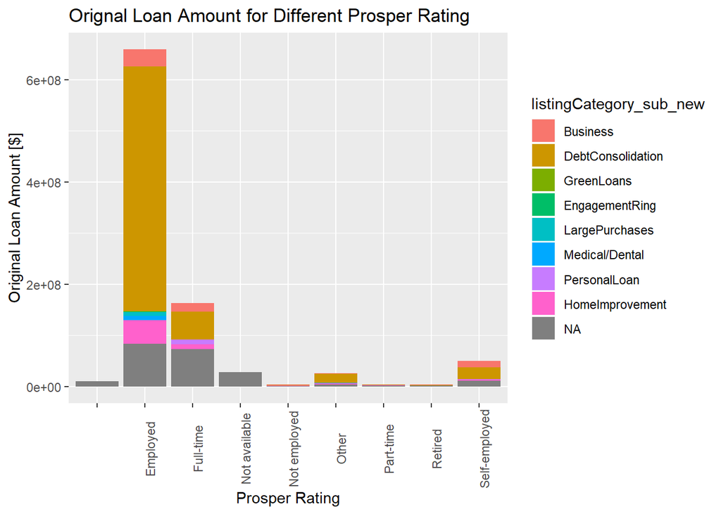

It is obvious that most loans are for debt consolidation.

# Multivariate Analysis

### Talk about some of the relationships you observed in this part of the

Investigation. Were there features that strengthened each other in terms of  
looking at your feature(s) of interest?

### Were there any interesting or surprising interactions between features?

Yes the most surprising is what the loans were used for, they were used for paying off other loans.

### OPTIONAL: Did you create any models with your dataset? Discuss the

strengths and limitations of your model. NO model was created

# Final Plots and Summary

### Plot One

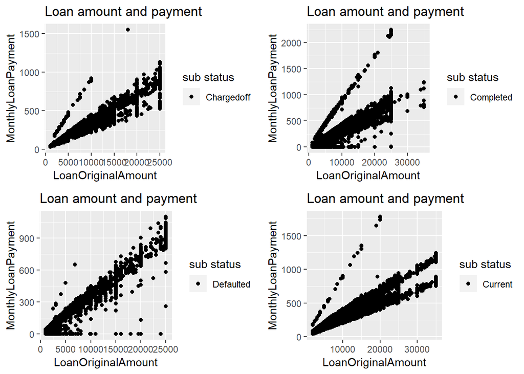

### Plot Two

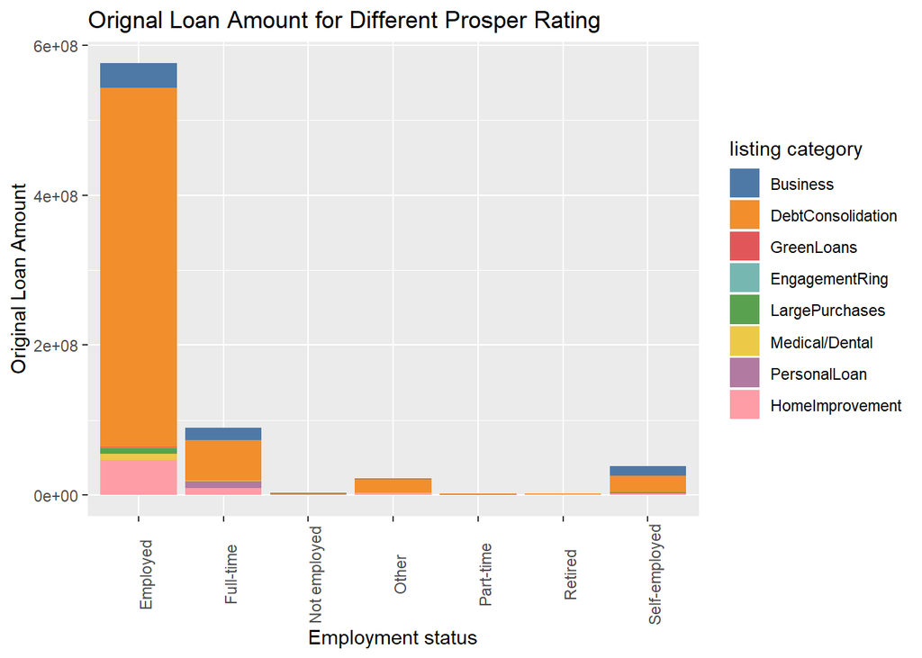

### Description Two

From above you will see a similar type of this plot above but with much noise, out of the plot i could figure ou that debt consolidation was very high acorss all employment status. This above plot shows that for every employment status the debt consolidation has a high percentage, showing that people borrow money to pay debt. This plot also showes that the employed people are the highest borrowers of loan.

### Plot Three

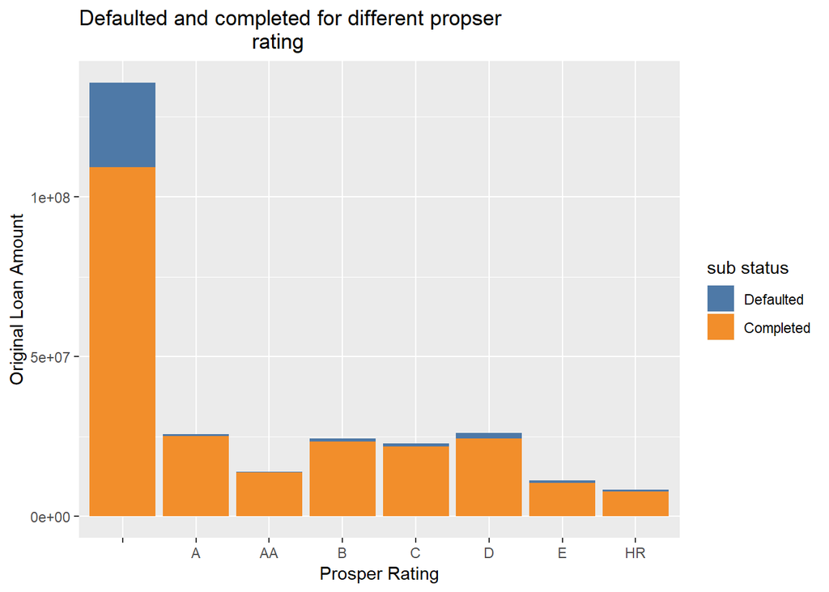

### Description Three

Having explore all the sub status from the beginning have decided to choose two statuses which is either you defaulted or you completed. the current status wont be of any help in the survey.

# Reflection

I chose this data set because it has to do with loan and i have always wanted to explore a loan data set.At the beginning, I didn’t know what to looking for in the data set. I trusted my self and believed that as i exlpore i will discover many insights.

I had struggle with some of the variable choosing which one to use with time I decided to choose the variable I understood , which gave me positive result like people borrowed loan to repay other loans.I also had issues with r syntaxes because am used to python. During my analysis, I verified that many variables that I have believed that would have a greater effect on Borrowers rate, actually were of little help.I had to go through each variable one by one, try to understand the meaning as I was not an expert in the finance or Accounting.

I also categorize loan status into default and completed as to areas that were discovered which need to be cleared out. I believe that if there were more exploration in the multivariable section putting a lot of variable into consideration it will expose more trends. Also, having only analysed 20 of the original 81 variables leaves a lot of undiscovered relationships and trends. As i progressed i saw that debt consolidation was wat most employed people use their loans for.

Future exlporation,i believe that a good machine learning model will be good for future exploration of this project.